# Breaking Bad - A Tale of Descent into Darkness

**Breaking Bad** is an American television series that aired from 2008 to 2013, created by **Vince Gilligan**. It is widely regarded as one of the greatest television series of all time and has garnered critical acclaim for its writing, acting, and cinematography.

*Breaking Bad* follows the story of **Walter White**, a high school chemistry teacher living in Albuquerque, New Mexico. Walter's life takes a drastic turn when he is diagnosed with terminal lung cancer, leaving him with only a few years to live. Faced with the prospect of leaving his family in financial ruin, Walter decides to use his chemistry expertise to cook and sell methamphetamine in order to secure their financial future.

As Walter delves deeper into the world of drug manufacturing, he teams up with his former student, **Jesse Pinkman**, a small-time methamphetamine producer and dealer. Together, they embark on a journey filled with danger, moral ambiguity, and unexpected consequences.

The series explores themes of morality, identity, and the consequences of one's actions. As Walter becomes increasingly involved in the criminal underworld, he grapples with his own morality and the impact of his choices on those around him. His transformation from a mild-mannered teacher to a ruthless drug lord is a central focus of the show.

*Breaking Bad* is known for its complex characters, intricate plot twists, and intense storytelling. It features standout performances from actors such as **Bryan Cranston** as Walter White, **Aaron Paul** as Jesse Pinkman, and **Anna Gunn** as Walter's wife, **Skyler White**.

Throughout its five-season run, *Breaking Bad* captivated audiences with its gripping narrative and stunning visuals. It received numerous awards and accolades, including 16 Primetime Emmy Awards.

With its unforgettable characters, gripping storyline, and thought-provoking themes, *Breaking Bad* remains a landmark achievement in television history, solidifying its place as a modern classic.

[figure not shown]

### Data Collection and Collected Columns

The data for this analysis was collected from various sources, including official episode guides, IMDb, and Wikipedia. The dataset includes information about each episode of the TV show "Breaking Bad," including details such as the episode number, title, director, writer, original air date, and US viewership.

The following table provides a description of each collected column:

| Variable | Description |
| --- | --- |
| number_overall | The overall episode number in the entire series. |
| number_in_season | The episode number within a particular season. |
| title | The title of the episode. |
| directed_by | The director(s) of the episode. |
| written_by | The writer(s) of the episode. |
| original_air_date | The original air date of the episode. |
| us_viewers | The number of viewers (in millions) who watched the episode during its initial US broadcast. |

```python
import pandas as pd
import matplotlib.pyplot as plt
import seaborn as sns
import plotly.graph_objs as go
```

```python
# Load the data
df = pd.read_csv("../data/breaking_bad_episodes.csv")

# Convert original_air_date to datetime
df['original_air_date'] = pd.to_datetime(df['original_air_date'])
```

```python
# Create season column
season_number = 1
prev_episode_number = 0
season_numbers = []

for index, row in df.iterrows():
    episode_number = row['number_in_season']

    if episode_number <= prev_episode_number:
        season_number += 1

    season_numbers.append(season_number)

    prev_episode_number = episode_number

df['season'] = season_numbers
```

```python
df.head(10)
```

[output not shown]

### Summary of Basic Statistics

```python
summary_stats = df.describe()
print(summary_stats.to_markdown())
```

```
|       |   number_overall |   number_in_season |   us_viewers |   season |
|:------|-----------------:|-------------------:|-------------:|---------:|
| count |          62      |           62       |     62       | 62       |
| mean  |          31.5    |            7.04839 |      2.23597 |  3.29032 |
| std   |          18.0416 |            4.07482 |      1.67457 |  1.35969 |
| min   |           1      |            1       |      0.97    |  1       |
| 25%   |          16.25   |            4       |      1.3225  |  2       |
| 50%   |          31.5    |            7       |      1.65    |  3       |
| 75%   |          46.75   |           10       |      2.2675  |  4.75    |
| max   |          62      |           16       |     10.28    |  5       |
```

These insights illuminate the show's popularity and structure, providing context for its enduring appeal.

### Exploratory Data Analysis (EDA) of Breaking Bad Viewership

Breaking Bad captivated audiences worldwide with its gripping storyline, complex characters, and intense drama. In this EDA section, we delve into the viewership trends of the acclaimed TV series. We analyze the data to uncover patterns, trends, and notable observations regarding the show's viewership over time.

```python
# Breaking Bad colors
colors = ['#009688', '#FFC107']

# Viewership Over Time
viewership_over_time = go.Scatter(x=df['original_air_date'], y=df['us_viewers'],
                                  mode='lines+markers', name='Viewership', line=dict(color=colors[0]))

layout = go.Layout(title='Viewership of Breaking Bad Over Time',
                   xaxis=dict(title='Original Air Date'),
                   yaxis=dict(title='Viewership'),
                   hovermode='closest',
                   plot_bgcolor='#212121',
                   paper_bgcolor='#424242',
                   font=dict(color='white'))

fig1 = go.Figure(data=[viewership_over_time], layout=layout)
fig1.show()
```

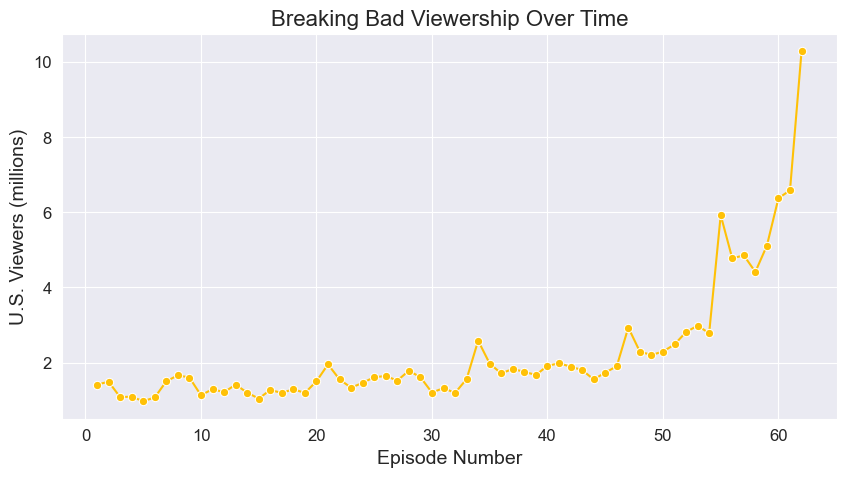

```python
sns.set_style("darkgrid")

plt.figure(figsize=(10, 5))
sns.lineplot(data=df, x='number_overall', y='us_viewers', marker='o', color='#FFC107')
plt.title('Breaking Bad Viewership Over Time', fontsize=16)
plt.xlabel('Episode Number', fontsize=14)
plt.ylabel('U.S. Viewers (millions)', fontsize=14)
plt.xticks(fontsize=12)
plt.yticks(fontsize=12)
plt.grid(True)
plt.show()
```

### Viewership of Breaking Bad Over Time

The plot below illustrates the viewership of Breaking Bad episodes over time. Here are some observations:

- **Trend:** Overall, the viewership of Breaking Bad episodes tends to fluctuate throughout the series.
- **Seasonal Patterns:** There are noticeable peaks and valleys in viewership, which could be attributed to various factors such as the intensity of the plot, marketing efforts, or external events.
- **Increasing Trend:** Despite fluctuations, there seems to be a general increasing trend in viewership, especially towards the later seasons.
- **Seasonal Differences:** Each season shows distinct patterns in viewership, with some seasons experiencing more significant fluctuations than others.
- **Episodic Changes:** Viewership can vary significantly from one episode to another within the same season, indicating the impact of individual plotlines and events on audience engagement.

Overall, the plot provides insights into the popularity and audience engagement of Breaking Bad throughout its airing, highlighting the dynamic nature of viewership trends over time.

```python
df['viewership_change'] = df['us_viewers'].diff()

df['viewership_change'].fillna(0, inplace=True)

# Episode-to-Episode Changes in Viewership
episode_changes = go.Bar(x=df['number_overall'], y=df['viewership_change'],
                         marker=dict(color=colors[1]), name='Viewership Changes')

layout = go.Layout(title='Episode-to-Episode Changes in Viewership',
                   xaxis=dict(title='Episode Number'),
                   yaxis=dict(title='Viewership Change'),
                   hovermode='closest',
                   plot_bgcolor='#212121',
                   paper_bgcolor='#424242',
                   font=dict(color='white'))

fig2 = go.Figure(data=[episode_changes], layout=layout)

fig2.show()
```

```python
# Viewership of Breaking Bad Episodes
episode_changes = go.Bar(x=df['number_overall'], y=df['us_viewers'],
                         marker=dict(color=colors[0]), name='Viewership')

layout = go.Layout(title='Viewership of Breaking Bad Episodes',
                   xaxis=dict(title='Episode Number'),
                   yaxis=dict(title='Viewership'),
                   hovermode='closest',
                   plot_bgcolor='#f0f0f0',
                   paper_bgcolor='#d9d9d9',
                   font=dict(color='#333333'))

fig4 = go.Figure(data=[episode_changes], layout=layout)
fig4.show()
```

### Episode-to-Episode Changes in Viewership

- **Fluctuations:** The bar heights indicate the change in viewership from one episode to the next. Positive values represent an increase in viewership, while negative values indicate a decrease.
- **Varying Magnitudes:** The magnitude of changes varies from episode to episode, with some episodes experiencing significant increases or decreases in viewership compared to the previous episode.
- **Patterns:** While there are fluctuations from episode to episode, certain patterns emerge, such as alternating increases and decreases in viewership over consecutive episodes.
- **Seasonal Trends:** Seasonal differences in viewership changes can also be observed, with some seasons showing more consistent trends while others exhibit greater variability.

Overall, the plot provides insights into the episodic fluctuations in viewership for Breaking Bad, highlighting the dynamic nature of audience engagement with each episode.

```python
season_wise_viewership = df.groupby('season')['us_viewers'].sum().reset_index()

season_wise_viewership['viewership_change'] = season_wise_viewership['us_viewers'].diff()
season_wise_viewership['viewership_change'].fillna(0, inplace=True)

season_diffs = go.Bar(x=season_wise_viewership['season'], y=season_wise_viewership['viewership_change'],
                      marker=dict(color=colors[1]), name='Viewership Change')

layout = go.Layout(title='Season-to-Season Changes in Viewership',
                   xaxis=dict(title='Season'),
                   yaxis=dict(title='Viewership Change'),
                   hovermode='closest',
                   plot_bgcolor='#212121',
                   paper_bgcolor='#424242',
                   font=dict(color='white'))

fig5 = go.Figure(data=[season_diffs], layout=layout)
fig5.show()
```

```python
season_viewership = df.groupby('season')['us_viewers'].sum().reset_index()

season_changes = go.Bar(x=season_viewership['season'], y=season_viewership['us_viewers'],
                        marker=dict(color=colors[0]), name='Viewership')

layout = go.Layout(title='Season-to-Season Changes in Viewership',
                   xaxis=dict(title='Season'),
                   yaxis=dict(title='Total Viewership'),
                   hovermode='closest',
                   plot_bgcolor='#212121',
                   paper_bgcolor='#424242',
                   font=dict(color='white'))

fig6 = go.Figure(data=[season_changes], layout=layout)
fig6.show()
```

### Season-to-Season Changes in Viewership

The viewership of Breaking Bad increased steadily from Season 1 to Season 5, with significant jumps observed between certain seasons:

- Season 1 had a viewership of 8.61 million, serving as the baseline.
- Season 2 experienced a notable increase, reaching 16.98 million viewers, indicating a viewership change of 8.37 million from the previous season.
- Season 3 continued the upward trend, with a viewership of 19.72 million, reflecting a 2.74 million increase from Season 2.
- Season 4 saw a substantial rise, reaching 24.27 million viewers, marking a significant increase of 4.55 million from the previous season.
- Season 5 witnessed the highest viewership, with 69.05 million viewers, indicating a remarkable surge of 44.78 million from Season 4.

Overall, the series experienced remarkable growth in viewership over its five seasons, with Season 5 standing out as the peak in terms of audience engagement.

[figure not shown]

```python
director_counts = df['written_by'].value_counts()

plt.figure(figsize=(10, 6))
director_counts.plot(kind='bar', color=colors[0])
plt.title('Top Directors with the Most Written Episodes')
plt.xlabel('Director')
plt.ylabel('Number of Episodes Written')
plt.xticks(rotation=45, ha='right')
plt.grid(axis='y', linestyle='--', alpha=0.7)
plt.show()
```

[figure not shown]

```python
director_viewership = df.groupby('written_by')['us_viewers'].sum().sort_values(ascending=False)

plt.figure(figsize=(10, 6))
director_viewership.plot(kind='bar', color=colors[1])
plt.title('Top Directors by Total Viewership')
plt.xlabel('Director')
plt.ylabel('Total Viewership (millions)')
plt.xticks(rotation=45, ha='right')
plt.grid(axis='y', linestyle='--', alpha=0.7)
plt.show()
```

```python
avg_episodes_per_season = df.groupby('season')['number_in_season'].max().mean()

# Number of episodes per season
avg_episodes_trace = go.Bar(x=df['season'].unique(), y=df.groupby('season')['number_in_season'].max(),
                            marker=dict(color=colors[0]))
layout = go.Layout(title='Number of Episodes per Season',
                   xaxis=dict(title='Season'),
                   yaxis=dict(title='Number of Episodes'),
                   plot_bgcolor='#f0f0f0',
                   paper_bgcolor='#f0f0f0',
                   font=dict(color='#333333'))
fig = go.Figure(data=[avg_episodes_trace], layout=layout)
fig.show()
```

```python
avg_viewership_per_episode = df.groupby('season')['us_viewers'].sum() / df.groupby('season')['number_in_season'].max()

# Average viewership per episode for each season
avg_viewership_trace = go.Bar(x=df['season'].unique(), y=avg_viewership_per_episode,
                              marker=dict(color=colors[1]))
layout = go.Layout(title='Average Viewership per Episode for Each Season',
                   xaxis=dict(title='Season'),
                   yaxis=dict(title='Average Viewership per Episode'),
                   plot_bgcolor='#f0f0f0',  # Background color
                   paper_bgcolor='#f0f0f0',  # Plot area color
                   font=dict(color='#333333'))  # Font color
fig = go.Figure(data=[avg_viewership_trace], layout=layout)
fig.show()
```

```python
print(f"The viewership increased by {abs(df[df['season'] == 3]['us_viewers'].mean() - df[df['season'] == 5]['us_viewers'].mean())} between seasons 3 and 5.")
```

```
The viewership increased by 2.798701923076923 between seasons 3 and 5.
```

### Summary Exploring Breaking Bad Viewership

Breaking Bad, a critically acclaimed television series created by Vince Gilligan, follows the transformation of a high school chemistry teacher, Walter White, into a ruthless drug lord. With its gripping storyline and compelling characters, Breaking Bad has captivated audiences worldwide.

#### Viewership Analysis

Through these visualizations and analyses, we gain a deeper understanding of the evolution of Breaking Bad's viewership and the contributions of its creators to its success.